# Little Lending Library

David F. Severski (@dseverski)

June 24, 2016

## Background

[This tweet](https://twitter.com/bhaskar_vk/status/745979370800553985) from @bhaskar_vk reminded me of the free lending library just a couple houses up from mine. I’ve seen a number of these lending libraries in and around Seattle and was curious as to how many there are across the US. I didn’t realize there was a full 501(c) set up around the concept nor that they had a web site from which the locations (with a little work) could be extracted. Quick, Robin! To the Bat RStudio!

## Parse the PDF

While there is a PDF published with all the data, it’s in a very awkward format and I could never get it to parse cleanly.

```r
library(tm)
library(httr)
```

```r
# uri <- "https://littlefreelibrary.org/wp-content/uploads/2013/08/World-Map-Appendix-Update-10.1.15.pdf",
# if (!file.exists("data/librarymap.pdf")) {
#   download.file(url = uri,
#                 destfile = "data/librarymap.pdf")
# }
#
# uri <- sprintf("file://%s", file.path(getwd(), "data/librarymap.pdf"))
# pdf <- readPDF(engine="xpdf", control=list(text = "-table"))(elem=list(uri = uri), language="en")
# data <- pdf$content
#
# col_widths <- c(8, (41-8), (52-41), (71-52), (84-71), (92-84), (149-92), (158-149), (167-158))
# col_names <- c("charter", "street_address", "city", "state", "postal", "library", "story", "lat", "long")
# dat <- read.fwf(textConnection(data), header=FALSE, fill=TRUE, row.names = NULL,
#                 widths = col_widths, col.names = col_names)
#
```

## Work with JSON

But, wait! There’s an embedded map widget which a little fiddling with devtools will allow us to grab a perfect little JSON array for all of the libraries in the US.

```r
library(jsonlite)
suppressWarnings(suppressMessages(library(jqr)))
suppressWarnings(suppressMessages(library(dplyr)))
library(stringi)
library(stringr)
data_file <- "data/libraries2.json"

if (!file.exists(data_file)) {
  # save on hits/bandwidth to the littlelibrary map API

  uri <- "https://littlefreelibrary.secure.force.com/apexremote"
  # request params derived from Firefox developer tools and using copy-as-cURL
  header <- c(Host = "littlefreelibrary.secure.force.com",
                 "User-Agent" = "Mozilla/5.0 (Windows NT 10.0; Win64; x64; rv:47.0) Gecko/20100101 Firefox/47.0",
                 "X-User-Agent" = "Visualforce-Remoting",
                 Accept = "text/html,application/xhtml+xml,application/xml;q=0.9,*/*;q=0.8",
                 "Accept-Language" = "en-US,en;q=0.5",
                 DNT = "1",
                 "X-Requested-With" = "XMLHttpRequest",
                 "Referer" = "https://littlefreelibrary.secure.force.com/mapPage")
  post_data <- paste0('{"action":"MapPageController","method":"remoteSearch",',
                      '"data":["US","Country",null,null],"type":"rpc","tid":5,',
                      '"ctx":{"csrf":"VmpFPSxNakF4Tmkwd05pMHlObFF4TmpveE1qb3dPQ',
                      'zR4TnpCYSxqMWk5QlVlREZvX0dFSFMyckowN2Y1LFpUTmhZelkw",',
                      '"vid":"066d00000027Meh","ns":"","ver":29}}')
  cookie <- c(BrowserId = "KPy-yRlLREKvcrfwms0OZw")

  r <- POST(uri, add_headers(header), set_cookies(cookie), body = post_data, content_type_json())
  bin <- content(r, "raw")
  writeBin(bin, data_file)
}

# use JQ to extract just the results and convert to a data.frame
dat <- jq(readLines(data_file, warn = FALSE),
          '[.[0].result | .[].library]') %>%
  fromJSON(., flatten = TRUE)

# clean up the names...why does the public map API return the email and exact location,
# even if the steward has requested that those not be displayed?!
names(dat) <- c("library_name", "steward_name", "steward_email",
                "charter_number", "exact_location", "email_display",
                "name_display", "street", "city", "country", "postal_code",
                "id", "library_story", "state", "lat", "long")

dat$country <- toupper(dat$country)
dat[dat$country == "USOFA","country"] <- "USA"
dat[dat$country == "US","country"] <- "USA"
dat <- filter(dat, country == "USA")

dat <- mutate(dat, state = toupper(state))

fix_state <- function(x) {
  # given a state name, try to convert it to a state abreviation
  if (x %in% state.abb) {
  } else {
    y <- stri_trans_totitle(x)
    if (y %in% state.name) {
      x <- state.abb[match(y, state.name)]
    }
  }
  x
}

# the state field is messy, apply some clean up logic
dat$state <- sapply(dat$state, fix_state)
dat$state <- gsub(".", "", dat$state, fixed = TRUE)
dat[dat$state == "ALL", "state"] <- "AL"
dat[dat$state == "WI WISCONSIN", "state"] <- "WI"
dat[dat$state == "MASSACUSETTS", "state"] <- "MA"
dat[dat$state == "NAPPANEE", "state"] <- "IN"
```

## Census Data

Just raw numbers of libraries doesn’t account for population size, etc. To try to scale, I’ll grab the current (2015) population estimates from the US Census beurau.

```r
library(readr)
if (!file.exists("data/census.csv")) {
  download.file("http://www.census.gov/popest/data/national/totals/2015/files/NST-EST2015-alldata.csv",
                destfile = "data/census.csv")
}
census <- read_csv("data/census.csv") %>% filter(!is.na(NAME))
census$state <- sapply(census$NAME, fix_state)
# population is in POPESTIMATE2015
```

## Join the data sets

```r
libraries_by_state <- group_by(dat, state) %>% tally()
libraries_by_state <- left_join(libraries_by_state, select(census, state, population = POPESTIMATE2015))
libraries_by_state %>% mutate(per_capita = n/population) -> libraries_by_state
```

## Plot the data

Using a graphical format demonstrated by @hrbrmstr, display the top 10 per capita states with lending libraries as well as the total number of libraries in each of those states.

Suggestion to scale per million population courtesy @bhaskar_vk.

This winds up being very useful. Vermont, for instance, is very high in terms of libraries per capita, but that is entirely due to the low population of the state.

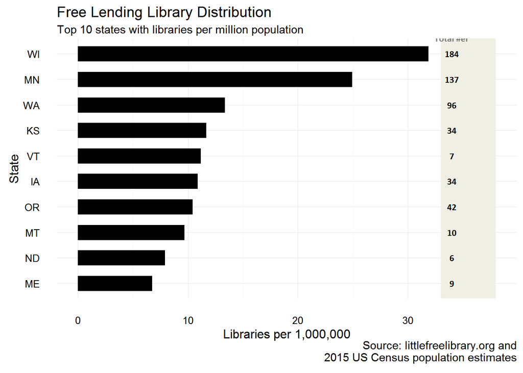

```r
library(ggplot2)
library(scales)
library(extrafont)
arrange(libraries_by_state, desc(per_capita)) %>% top_n(10) %>%
  mutate(per_capita = per_capita) -> plot_data
plot_data$state <- factor(plot_data$state,
                          levels = plot_data[order(plot_data$per_capita, decreasing = FALSE), ]$state,
                          ordered = TRUE)

gg <- ggplot(plot_data, aes(y = per_capita * 1000000, x = state, label = n))
gg <- gg + geom_segment(aes(y = 0, yend = per_capita * 1000000, x = state,
                            xend = state), size = 7)
#gg <- gg + geom_text(hjust = 0, nudge_y = .001, size = 3)
gg <- gg + scale_y_continuous(labels = comma)
gg <- gg + labs(y = "Libraries per 1,000,000", x = "State",
                title = "Free Lending Library Distribution",
                subtitle = "Top 10 states with libraries per million population",
                caption = "Source: littlefreelibrary.org and\n2015 US Census population estimates")

# the total library count column
# column derived from technique demonstrated by @hrbrmstr
gg <- gg + geom_rect(data = plot_data, aes(ymin = 33, ymax = 38,
                                           xmin = -Inf, xmax = Inf),
                     fill = "#efefe3")
gg <- gg + geom_text(data = plot_data, aes(label = n, x = state, y = 34),
                     fontface = "bold", size = 3, family = "Calibri")
gg <- gg + geom_text(data = filter(plot_data, state == "WI"),
                     aes(y = 34, x = state, label = "Total #er"),
                     color = "#7a7d7e", size = 3.1, vjust = -2, fontface = "bold",
                     family = "Calibri")
#gg <- gg + scale_x_continuous(expand=c(0,0), limits=c(0, 38))
#gg <- gg + scale_y_discrete(expand=c(0.075,0))

gg <- gg + coord_flip()
gg <- gg + theme_bw(base_family = "Calibri")
gg <- gg + theme(panel.grid.major = element_blank())
gg <- gg + theme(panel.grid.minor = element_blank())
gg <- gg + theme(panel.border = element_blank())
gg <- gg + theme(plot.title = element_text(face = "bold"))
gg <- gg + theme(plot.subtitle = element_text(face = "italic", size = 9,
                                              margin = margin(b = 12)))
gg <- gg + theme(plot.caption = element_text(size = 7, margin = margin(t = 12),
                                             color = "#7a7d7e"))
gg <- gg + theme_minimal()

gg
```

## Further Exploration on Seattle Metro Region

I intended to use the free zip code database from http://www.unitedstateszipcodes.org/zip-code-database/, but my downloads were never succesfull. Instead, I used the encoded city column from the map API, even though that has some questionable entries.

```r
# zips <- read_csv("data/zip_code_database.csv")
# seattle_zips <- c("98103", "98102")
# dat %>% filter(postal_code == "98103")

dat <- dat %>% mutate(city = str_to_title(city))

# Seattle is #3 in total number of libraries
dat %>% group_by(state, city) %>% tally()
```

```
## Source: local data frame [646 x 3]
## Groups: state [?]
##
##    state          city     n
##    (chr)         (chr) (int)
## 1     AL        Auburn     1
## 2     AL    Huntsville     2
## 3     AL         Moody     1
## 4     AL         Ozark     1
## 5     AR  Fayetteville     3
## 6     AR  Feyetteville     1
## 7     AR Mountain Home     1
## 8     AR       Norfork     1
## 9     AR        Rogers     1
## 10    AR     Texarkana     1
## ..   ...           ...   ...
```

```r
# One steward is associated with 19 libraries!
# Kimberly Daugherty, but they're all associated with a single address
dat %>% group_by(steward_name) %>% tally()  %>% arrange(desc(n)) %>% top_n(10)
```

```
## Source: local data frame [18 x 2]
##
##               steward_name     n
##                      (chr) (int)
## 1       Kimberly Daugherty    19
## 2                 Deb West     6
## 3          Melissa Higgins     6
## 4              Katie Quinn     5
## 5               Gary Davis     4
## 6            Marie Johnson     4
## 7          Christine Barth     3
## 8          Barb Shillinger     2
## 9  Friends of Beckman Mill     2
## 10           J. A. Senesac     2
## 11            Kaye Johnson     2
## 12             Kim Carlson     2
## 13            Kolstad Rita     2
## 14            Laurie Marks     2
## 15             Maggie Vold     2
## 16          Patrick Hester     2
## 17     Priscilla Woolworth     2
## 18         Richard Venberg     2
```

```r
# There are 1142 unique charter numbers, but 1150 registered libraries
length(unique(dat$charter_number))
```

```
## [1] 1142
```